# Emotional support

# 1 Description of DataSchema variable

The description of harmonised variable is the following:

- Short name: `emot_sup`
- Variable label: `Receives emotional support from someone`
- Variable description: `Receives emotional support from someone (i.e. has someone to count on, people show concern in what s/he is doing, etc.)`
- Domain: `Social environment`
- Value type: `categorical`
- Category coding:

| **Code** | **Category Label** |
| --- | --- |
| 0 | No |
| 1 | Yes |

- Category missings:

| **Code** | **Category Label** |
| --- | --- |
| 991 | CAPI/interviewer error |
| 992 | Impute |
| 993 | Disable to measure |
| 994 | Not attempt/not done |
| 995 | Does not answer |
| 996 | Not applicable |
| 997 | Refuse |
| 998 | Do not know |
| 999 | Missing |

# 2 Data process

## 2.1 England

### 2.1.1 Wave 1

#### 2.1.1.1 Study-specific variable description

| **Name** | `scptra` | `scptrb` | `scptrc` | `scchda` | `scchdb` | `scchdc` | `scfama` | `scfamb` | `scfamc` | `scfrda` | `scfrdb` | `scfrdc` |
| --- | --- | --- | --- | --- | --- | --- | --- | --- | --- | --- | --- | --- |
| **Label** | `how much does your spouse/partner really understand the way you feel?` | `how much can you rely on your spouse/partner if you have a serious problem?` | `how much can you open up to your spouse/partner if you need to talk about your worries?` | `how much do your children really understand the way you feel about things?` | `how much can you rely on your children if you have a serious problem?` | `how much can you open up to your children if you need to talk about your worries?` | `how much do these family members really understand the way you feel?` | `how much can you rely on these family members if you have a serious problem?` | `how much can you open up to these family members if you need to talk about your worries?` | `how much do your friends really understand the way you feel about things?` | `how much can you rely on these friends if you have a serious problem?` | `how much can you open up to these friends if you need to talk about your worries?` |
| **Table name** | `wave_1_core_data_v3` | `wave_1_core_data_v3` | `wave_1_core_data_v3` | `wave_1_core_data_v3` | `wave_1_core_data_v3` | `wave_1_core_data_v3` | `wave_1_core_data_v3` | `wave_1_core_data_v3` | `wave_1_core_data_v3` | `wave_1_core_data_v3` | `wave_1_core_data_v3` | `wave_1_core_data_v3` |
| **Categories** | `1 = A lot` `2 = Some` `3 = A little` `4 = Not at all` | `1 = A lot` `2 = Some` `3 = A little` `4 = Not at all` | `1 = A lot` `2 = Some` `3 = A little` `4 = Not at all` | `1 = A lot` `2 = Some` `3 = A little` `4 = Not at all` | `1 = A lot` `2 = Some` `3 = A little` `4 = Not at all` | `1 = A lot` `2 = Some` `3 = A little` `4 = Not at all` | `1 = A lot` `2 = Some` `3 = A little` `4 = Not at all` | `1 = A lot` `2 = Some` `3 = A little` `4 = Not at all` | `1 = A lot` `2 = Some` `3 = A little` `4 = Not at all` | `1 = A lot` `2 = Some` `3 = A little` `4 = Not at all` | `1 = A lot` `2 = Some` `3 = A little` `4 = Not at all` | `1 = A lot` `2 = Some` `3 = A little` `4 = Not at all` |
| **Missings** | `-9 = Not answered` `-1 = Item not applicable` | `-9 = Not answered` `-1 = Item not applicable` | `-9 = Not answered` `-1 = Item not applicable` | `-9 = Not answered` `-1 = Item not applicable` | `-9 = Not answered` `-1 = Item not applicable` | `-9 = Not answered` `-1 = Item not applicable` | `-9 = Not answered` `-1 = Item not applicable` | `-9 = Not answered` `-1 = Item not applicable` | `-9 = Not answered` `-1 = Item not applicable` | `-9 = Not answered` `-1 = Item not applicable` | `-9 = Not answered` `-1 = Item not applicable` | `-9 = Not answered` `-1 = Item not applicable` |
| **Description** |  |  |  |  |  |  |  |  |  |  |  |  |

scptra

| Sample size | Missing values |
| --- | --- |
| 12099 | 4252 |

Category

|  | 1 | 2 | 3 | 4 |
| --- | --- | --- | --- | --- |
| Frequency | 4706.0 | 2431.00 | 572.00 | 138.00 |
| Percentage | 38.9 | 20.09 | 4.73 | 1.14 |

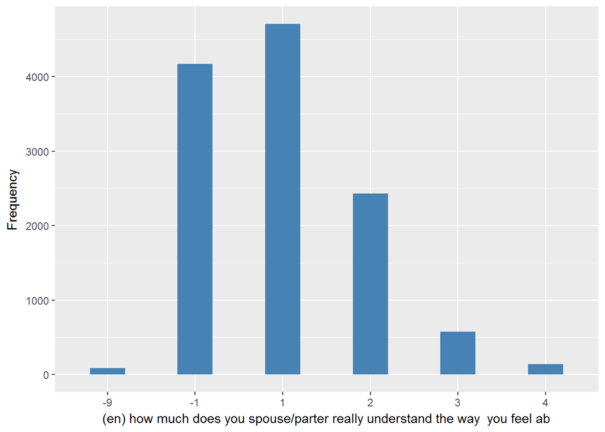

scptrb

| Sample size | Missing values |
| --- | --- |
| 12099 | 4221 |

Category

|  | 1 | 2 | 3 | 4 |
| --- | --- | --- | --- | --- |
| Frequency | 6961.00 | 573.00 | 239.00 | 105.00 |
| Percentage | 57.53 | 4.74 | 1.98 | 0.87 |

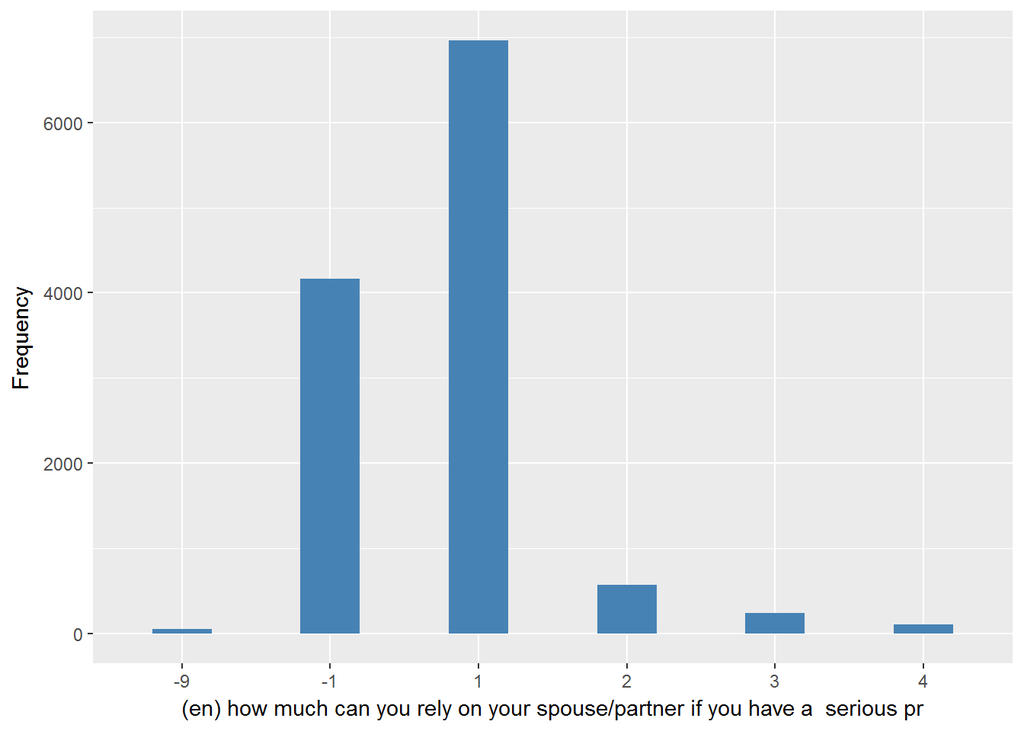

scptrc

| Sample size | Missing values |
| --- | --- |
| 12099 | 4233 |

Category

|  | 1 | 2 | 3 | 4 |
| --- | --- | --- | --- | --- |
| Frequency | 5378.00 | 1746.00 | 561.00 | 181.0 |
| Percentage | 44.45 | 14.43 | 4.64 | 1.5 |

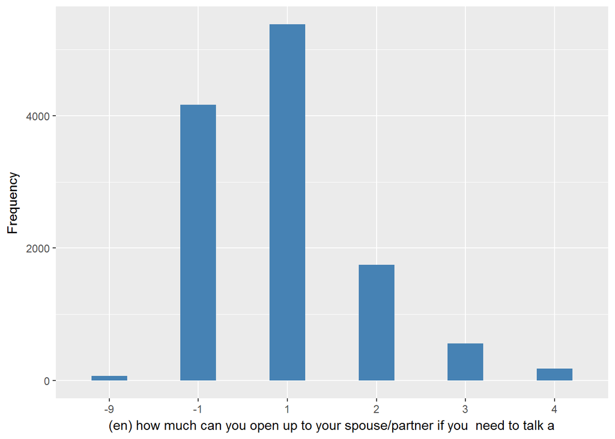

scchda

| Sample size | Missing values |
| --- | --- |
| 12099 | 2821 |

Category

|  | 1 | 2 | 3 | 4 |
| --- | --- | --- | --- | --- |
| Frequency | 4027.00 | 3867.00 | 1117.00 | 267.00 |
| Percentage | 33.28 | 31.96 | 9.23 | 2.21 |

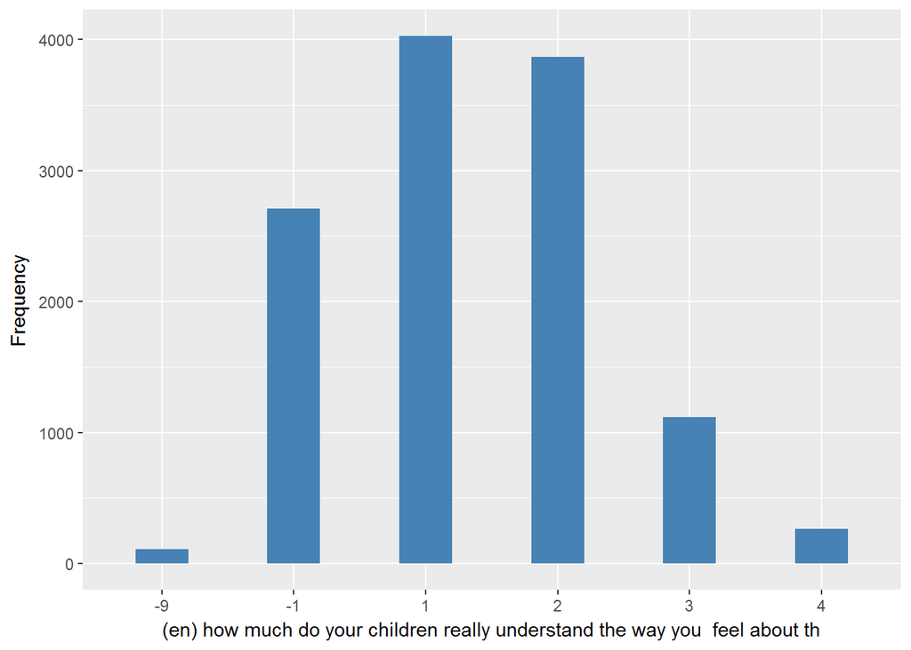

scchdb

| Sample size | Missing values |
| --- | --- |
| 12099 | 2789 |

Category

|  | 1 | 2 | 3 | 4 |
| --- | --- | --- | --- | --- |
| Frequency | 7104.00 | 1363.00 | 575.00 | 268.00 |
| Percentage | 58.72 | 11.27 | 4.75 | 2.22 |

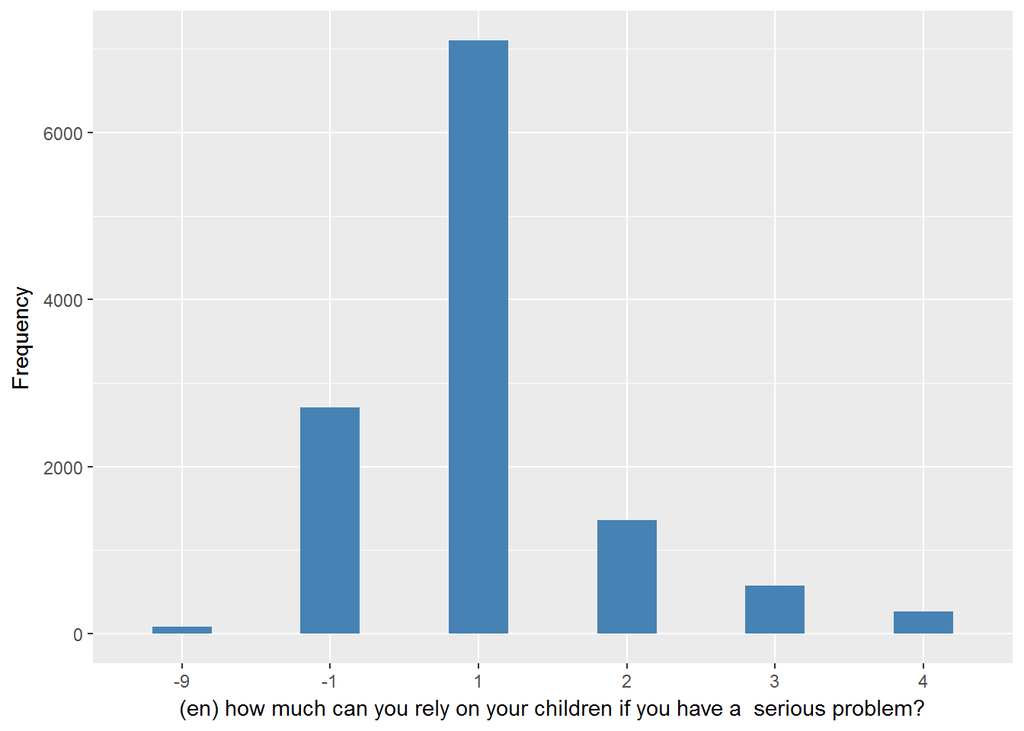

scchdc

| Sample size | Missing values |
| --- | --- |
| 12099 | 2815 |

Category

|  | 1 | 2 | 3 | 4 |
| --- | --- | --- | --- | --- |
| Frequency | 4704.00 | 2909.00 | 1216.00 | 455.00 |
| Percentage | 38.88 | 24.04 | 10.05 | 3.76 |

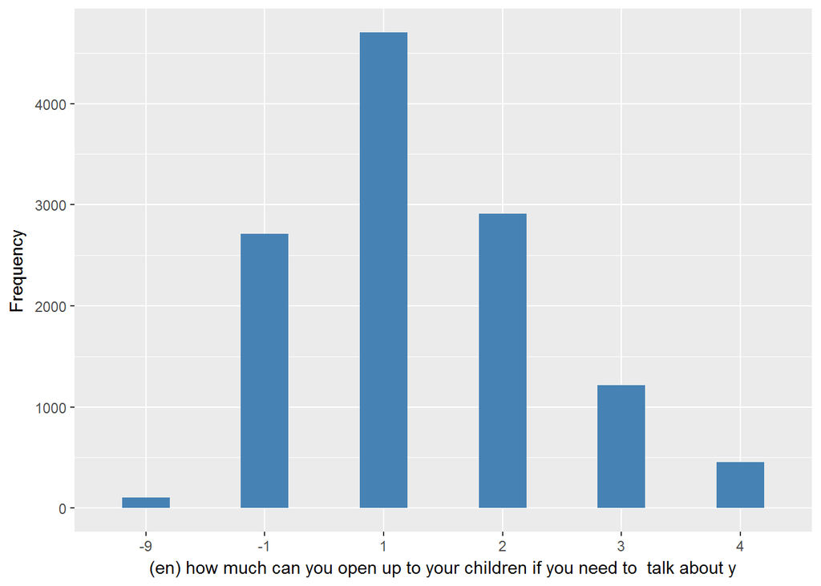

scfama

| Sample size | Missing values |
| --- | --- |
| 12099 | 2556 |

Category

|  | 1 | 2 | 3 | 4 |
| --- | --- | --- | --- | --- |
| Frequency | 2289.00 | 3597.00 | 2502.00 | 1155.00 |
| Percentage | 18.92 | 29.73 | 20.68 | 9.55 |

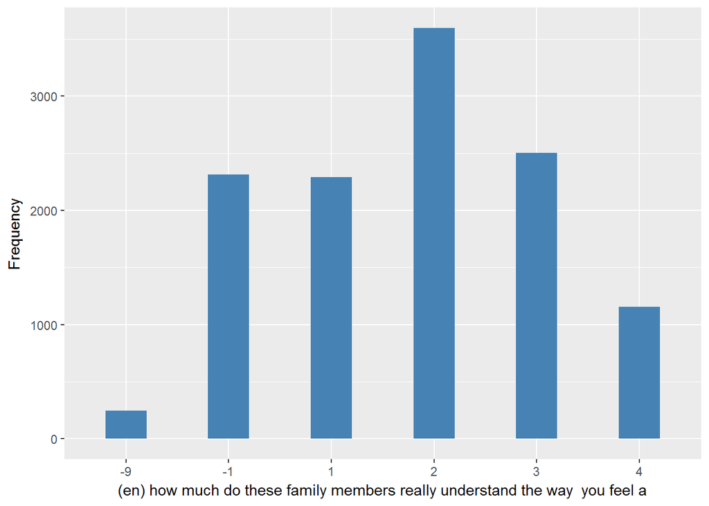

scfamb

| Sample size | Missing values |
| --- | --- |
| 12099 | 2528 |

Category

|  | 1 | 2 | 3 | 4 |
| --- | --- | --- | --- | --- |
| Frequency | 4536.00 | 2216.00 | 1611.00 | 1208.00 |
| Percentage | 37.49 | 18.32 | 13.32 | 9.98 |

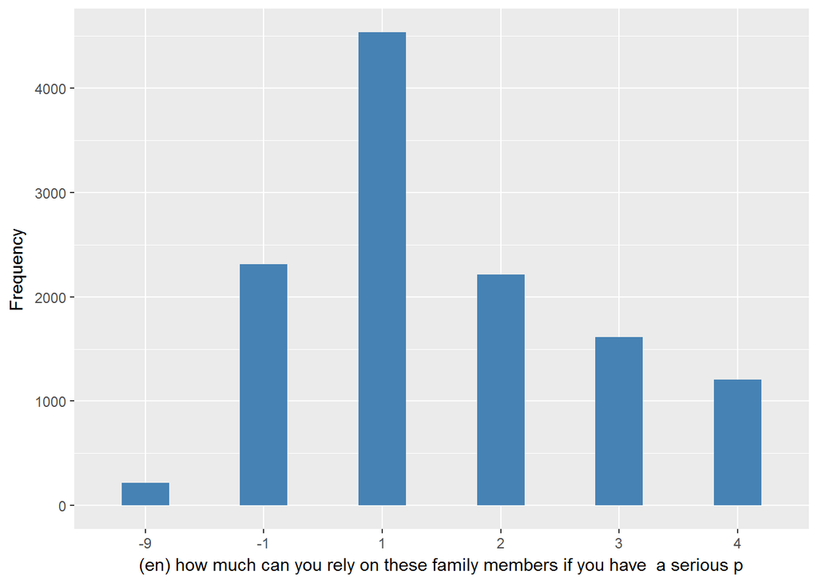

scfamc

| Sample size | Missing values |
| --- | --- |
| 12099 | 2551 |

Category

|  | 1 | 2 | 3 | 4 |
| --- | --- | --- | --- | --- |
| Frequency | 2971.00 | 2841.00 | 2167.00 | 1569.00 |
| Percentage | 24.56 | 23.48 | 17.91 | 12.97 |

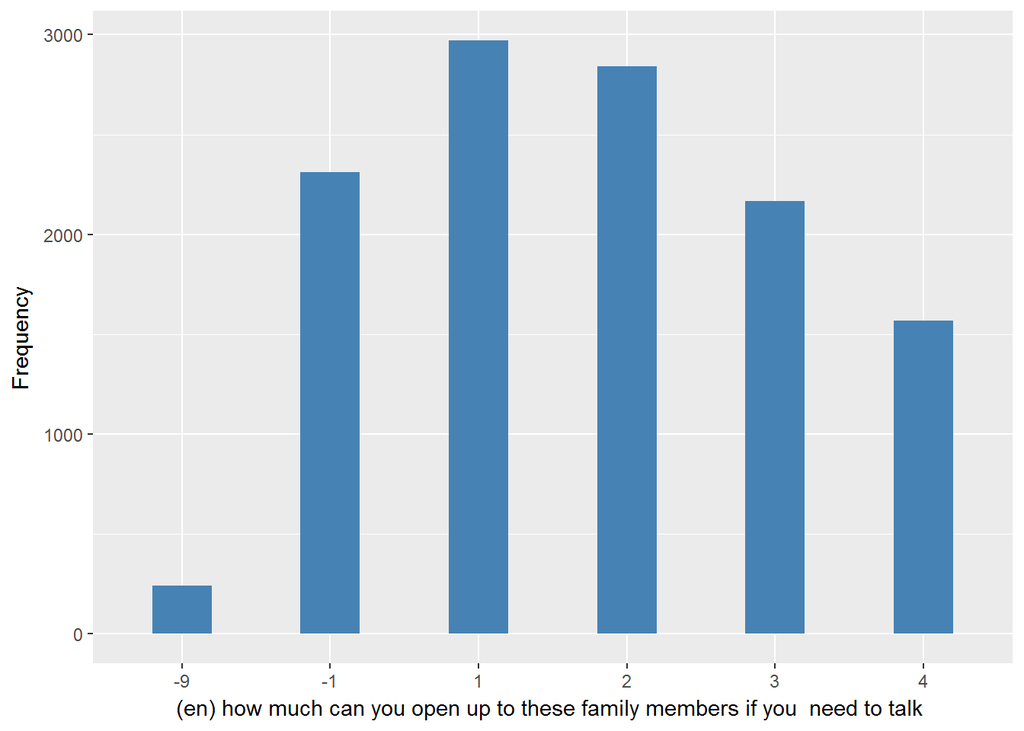

scfrda

| Sample size | Missing values |
| --- | --- |
| 12099 | 2184 |

Category

|  | 1 | 2 | 3 | 4 |
| --- | --- | --- | --- | --- |
| Frequency | 3551.00 | 4199.00 | 1949.00 | 216.00 |
| Percentage | 29.35 | 34.71 | 16.11 | 1.79 |

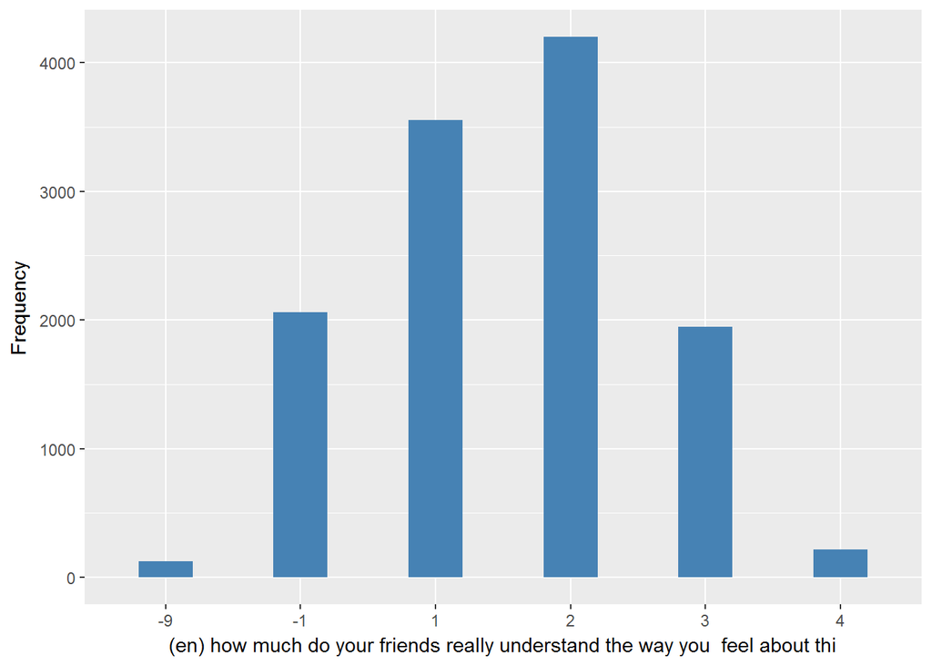

scfrdb

| Sample size | Missing values |
| --- | --- |
| 12099 | 2167 |

Category

|  | 1 | 2 | 3 | 4 |
| --- | --- | --- | --- | --- |
| Frequency | 4902.00 | 3112.00 | 1526.00 | 392.00 |
| Percentage | 40.52 | 25.72 | 12.61 | 3.24 |

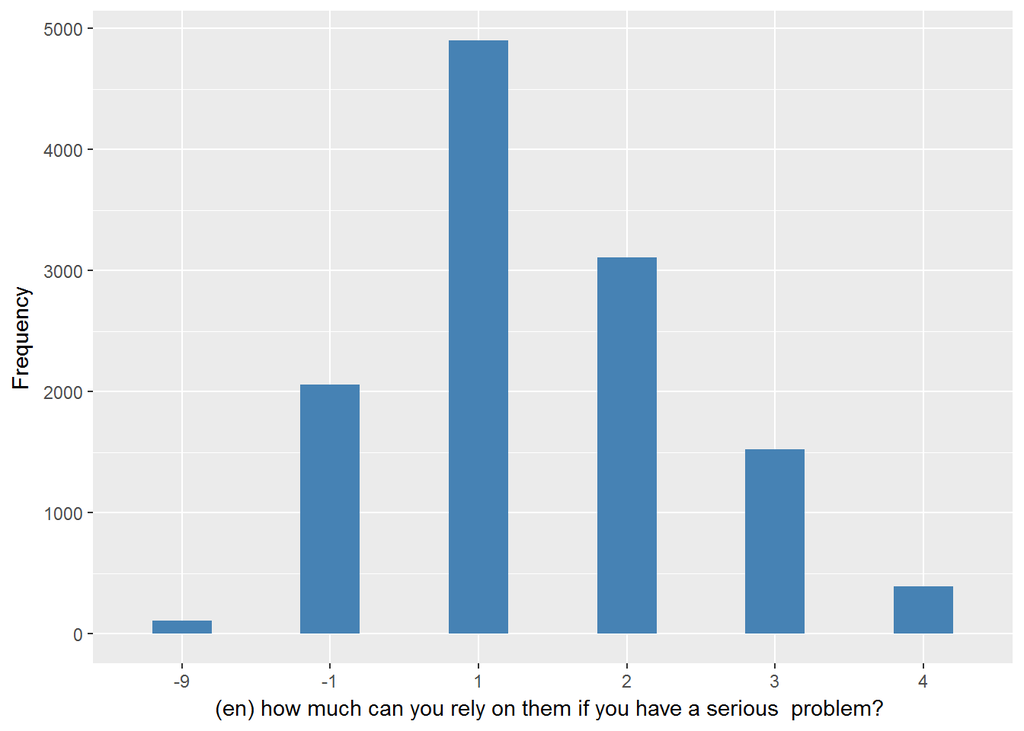

scfrdc

| Sample size | Missing values |
| --- | --- |
| 12099 | 2182 |

Category

|  | 1 | 2 | 3 | 4 |
| --- | --- | --- | --- | --- |
| Frequency | 3818.00 | 3391.00 | 2083.00 | 625.00 |
| Percentage | 31.56 | 28.03 | 17.22 | 5.17 |

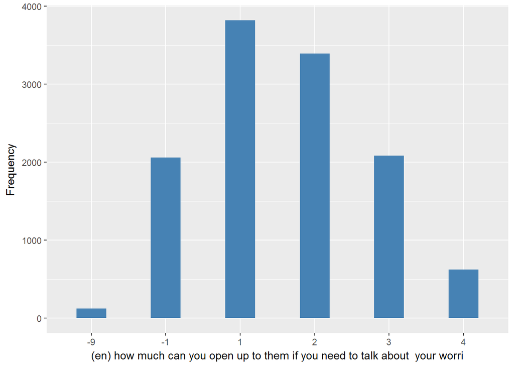

#### 2.1.1.2 Harmonisation algorithm

To compute the harmonize variable from the study-specific variable it has to be recoded as follows:

- `if any variable equals 1 or 2 then 1`
- `if all are equal 3 or 4 then 0`
- `-1 into 996`
- `-9 into 995`
- `NA into 999`

**R script:**

```r
ELSA_ds_w1 <- tibble(id = ELSA_w1_emot_sup$id)

ELSA_w1_emot_sup$scptra <- car::recode(as.vector(ELSA_w1_emot_sup$scptra), "NA='-999'")
ELSA_w1_emot_sup$scptrb <- car::recode(as.vector(ELSA_w1_emot_sup$scptrb), "NA='-999'")
ELSA_w1_emot_sup$scptrc <- car::recode(as.vector(ELSA_w1_emot_sup$scptrc), "NA='-999'")
ELSA_w1_emot_sup$scchda <- car::recode(as.vector(ELSA_w1_emot_sup$scchda), "NA='-999'")
ELSA_w1_emot_sup$scchdb <- car::recode(as.vector(ELSA_w1_emot_sup$scchdb), "NA='-999'")
ELSA_w1_emot_sup$scchdc <- car::recode(as.vector(ELSA_w1_emot_sup$scchdc), "NA='-999'")
ELSA_w1_emot_sup$scfama <- car::recode(as.vector(ELSA_w1_emot_sup$scfama), "NA='-999'")
ELSA_w1_emot_sup$scfamb <- car::recode(as.vector(ELSA_w1_emot_sup$scfamb), "NA='-999'")
ELSA_w1_emot_sup$scfamc <- car::recode(as.vector(ELSA_w1_emot_sup$scfamc), "NA='-999'")
ELSA_w1_emot_sup$scfrda <- car::recode(as.vector(ELSA_w1_emot_sup$scfrda), "NA='-999'")
ELSA_w1_emot_sup$scfrdb <- car::recode(as.vector(ELSA_w1_emot_sup$scfrdb), "NA='-999'")
ELSA_w1_emot_sup$scfrdc <- car::recode(as.vector(ELSA_w1_emot_sup$scfrdc), "NA='-999'")


ELSA_ds_w1$emot_sup <- c(NA)
for (i in 1:dim(ELSA_w1_emot_sup)[1]) {
    if (ELSA_w1_emot_sup$scptra[i] %in% c(1, 2) | ELSA_w1_emot_sup$scptrb[i] %in%
        c(1, 2) | ELSA_w1_emot_sup$scptrc[i] %in% c(1, 2) | ELSA_w1_emot_sup$scchda[i] %in%
        c(1, 2) | ELSA_w1_emot_sup$scchdb[i] %in% c(1, 2) | ELSA_w1_emot_sup$scchdc[i] %in%
        c(1, 2) | ELSA_w1_emot_sup$scfama[i] %in% c(1, 2) | ELSA_w1_emot_sup$scfamb[i] %in%
        c(1, 2) | ELSA_w1_emot_sup$scfamc[i] %in% c(1, 2) | ELSA_w1_emot_sup$scfrda[i] %in%
        c(1, 2) | ELSA_w1_emot_sup$scfrdb[i] %in% c(1, 2) | ELSA_w1_emot_sup$scfrdc[i] %in%
        c(1, 2)) {
        ELSA_ds_w1$emot_sup[i] = 1
    } else if (ELSA_w1_emot_sup$scptra[i] == -1 & ELSA_w1_emot_sup$scptrb[i] ==
        -1 & ELSA_w1_emot_sup$scptrc[i] == -1 & ELSA_w1_emot_sup$scchda[i] ==
        -1 & ELSA_w1_emot_sup$scchdb[i] == -1 & ELSA_w1_emot_sup$scchdc[i] ==
        -1 & ELSA_w1_emot_sup$scfama[i] == -1 & ELSA_w1_emot_sup$scfamb[i] ==
        -1 & ELSA_w1_emot_sup$scfamc[i] == -1 & ELSA_w1_emot_sup$scfrda[i] ==
        -1 & ELSA_w1_emot_sup$scfrdb[i] == -1 & ELSA_w1_emot_sup$scfrdc[i] ==
        -1) {
        ELSA_ds_w1$emot_sup[i] = 996
    } else if (ELSA_w1_emot_sup$scptra[i] %in% c(3, 4, -1) & ELSA_w1_emot_sup$scptrb[i] %in%
        c(3, 4, -1) & ELSA_w1_emot_sup$scptrc[i] %in% c(3, 4, -1) & ELSA_w1_emot_sup$scchda[i] %in%
        c(3, 4, -1) & ELSA_w1_emot_sup$scchdb[i] %in% c(3, 4, -1) & ELSA_w1_emot_sup$scchdc[i] %in%
        c(3, 4, -1) & ELSA_w1_emot_sup$scfama[i] %in% c(3, 4, -1) & ELSA_w1_emot_sup$scfamb[i] %in%
        c(3, 4, -1) & ELSA_w1_emot_sup$scfamc[i] %in% c(3, 4, -1) & ELSA_w1_emot_sup$scfrda[i] %in%
        c(3, 4, -1) & ELSA_w1_emot_sup$scfrdb[i] %in% c(3, 4, -1) & ELSA_w1_emot_sup$scfrdc[i] %in%
        c(3, 4, -1)) {
        ELSA_ds_w1$emot_sup[i] = 0
    } else if (ELSA_w1_emot_sup$scptra[i] == -9 | ELSA_w1_emot_sup$scptrb[i] ==
        -9 | ELSA_w1_emot_sup$scptrc[i] == -9 | ELSA_w1_emot_sup$scchda[i] ==
        -9 | ELSA_w1_emot_sup$scchdb[i] == -9 | ELSA_w1_emot_sup$scchdc[i] ==
        -9 | ELSA_w1_emot_sup$scfama[i] == -9 | ELSA_w1_emot_sup$scfamb[i] ==
        -9 | ELSA_w1_emot_sup$scfamc[i] == -9 | ELSA_w1_emot_sup$scfrda[i] ==
        -9 | ELSA_w1_emot_sup$scfrdb[i] == -9 | ELSA_w1_emot_sup$scfrdc[i] ==
        -9) {
        ELSA_ds_w1$emot_sup[i] = 995
    }
}

ELSA_ds_w1$emot_sup <- car::recode(as.vector(ELSA_ds_w1$emot_sup), "NA='999'")
ELSA_ds_w1$emot_sup <- labelled(ELSA_ds_w1$emot_sup, labels = c(No = 0, Yes = 1,
    Missing = 999, `Do not know` = 998, Refuse = 997, `Not applicable` = 996,
    `Don't answer` = 995, `Not attempt/not done/not yet recorded` = 994, `Disable to measure` = 993,
    Impute = 992, `CAPI/interviewer error` = 991))
```

#### 2.1.1.3 Statistics of the new harmonised variable

Receives emotional support from someone

| Sample size | Missing values |
| --- | --- |
| 12099 | 1221 |

Category

|  | 0 | 1 |
| --- | --- | --- |
| Frequency | 61.0 | 10817.0 |
| Percentage | 0.5 | 89.4 |

Type of missing

|  | 991 | 992 | 993 | 994 | 995 | 996 | 997 | 998 | 999 | NA |
| --- | --- | --- | --- | --- | --- | --- | --- | --- | --- | --- |
| Frequency | 0 | 0 | 0 | 0 | 35.00 | 1186.0 | 0 | 0 | 0 | 0 |
| Percentage | 0 | 0 | 0 | 0 | 0.29 | 9.8 | 0 | 0 | 0 | 0 |

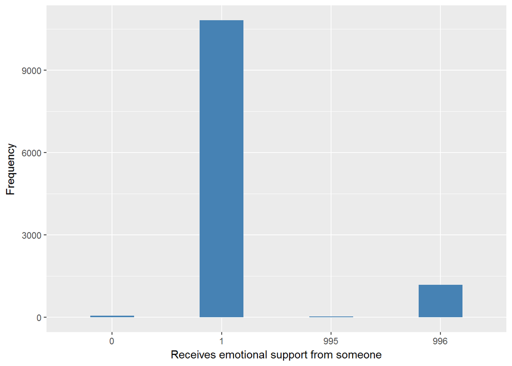

#### 2.1.1.4 Validation

### 2.1.2 Wave 2

#### 2.1.2.1 Study-specific variable description

| **Name** | `scptra` | `scptrb` | `scptrc` | `scchda` | `scchdb` | `scchdc` | `scfama` | `scfamb` | `scfamc` | `scfrda` | `scfrdb` | `scfrdc` |
| --- | --- | --- | --- | --- | --- | --- | --- | --- | --- | --- | --- | --- |
| **Label** | `how much does your spouse/partner really understand the way you feel?` | `how much can you rely on your spouse/partner if you have a serious problem?` | `how much can you open up to your spouse/partner if you need to talk about your worries?` | `how much do your children really understand the way you feel about things?` | `how much can you rely on your children if you have a serious problem?` | `how much can you open up to your children if you need to talk about your worries?` | `how much do these family members really understand the way you feel?` | `how much can you rely on these family members if you have a serious problem?` | `how much can you open up to these family members if you need to talk about your worries?` | `how much do your friends really understand the way you feel about things?` | `how much can you rely on these friends if you have a serious problem?` | `how much can you open up to these friends if you need to talk about your worries?` |
| **Table name** | `wave_2_core_data_v4` | `wave_2_core_data_v4` | `wave_2_core_data_v4` | `wave_2_core_data_v4` | `wave_2_core_data_v4` | `wave_2_core_data_v4` | `wave_2_core_data_v4` | `wave_2_core_data_v4` | `wave_2_core_data_v4` | `wave_2_core_data_v4` | `wave_2_core_data_v4` | `wave_2_core_data_v4` |
| **Categories** | `1 = A lot` `2 = Some` `3 = A little` `4 = Not at all` | `1 = A lot` `2 = Some` `3 = A little` `4 = Not at all` | `1 = A lot` `2 = Some` `3 = A little` `4 = Not at all` | `1 = A lot` `2 = Some` `3 = A little` `4 = Not at all` | `1 = A lot` `2 = Some` `3 = A little` `4 = Not at all` | `1 = A lot` `2 = Some` `3 = A little` `4 = Not at all` | `1 = A lot` `2 = Some` `3 = A little` `4 = Not at all` | `1 = A lot` `2 = Some` `3 = A little` `4 = Not at all` | `1 = A lot` `2 = Some` `3 = A little` `4 = Not at all` | `1 = A lot` `2 = Some` `3 = A little` `4 = Not at all` | `1 = A lot` `2 = Some` `3 = A little` `4 = Not at all` | `1 = A lot` `2 = Some` `3 = A little` `4 = Not at all` |
| **Missings** | `-9 = Not answered` `-1 = Item not applicable` | `-9 = Not answered` `-1 = Item not applicable` | `-9 = Not answered` `-1 = Item not applicable` | `-9 = Not answered` `-1 = Item not applicable` | `-9 = Not answered` `-1 = Item not applicable` | `-9 = Not answered` `-1 = Item not applicable` | `-9 = Not answered` `-1 = Item not applicable` | `-9 = Not answered` `-1 = Item not applicable` | `-9 = Not answered` `-1 = Item not applicable` | `-9 = Not answered` `-1 = Item not applicable` | `-9 = Not answered` `-1 = Item not applicable` | `-9 = Not answered` `-1 = Item not applicable` |
| **Description** |  |  |  |  |  |  |  |  |  |  |  |  |

scptra

| Sample size | Missing values |
| --- | --- |
| 9432 | 3537 |

Category

|  | 1 | 2 | 3 | 4 |
| --- | --- | --- | --- | --- |
| Frequency | 3494.00 | 1883.00 | 417.00 | 101.00 |
| Percentage | 37.04 | 19.96 | 4.42 | 1.07 |

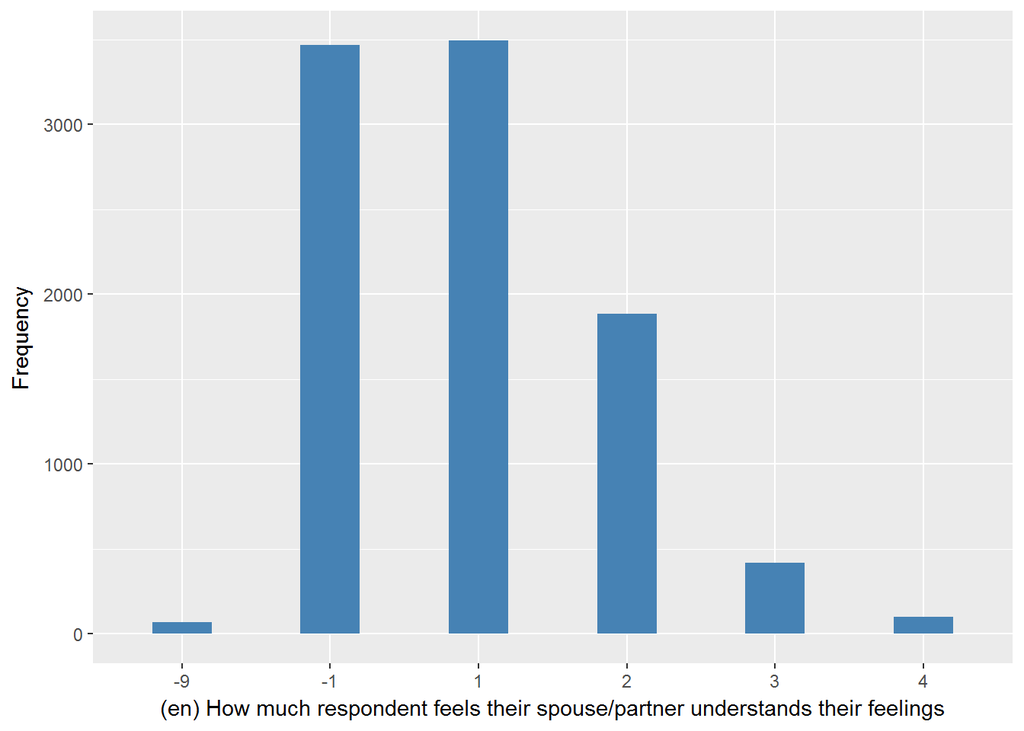

scptrb

| Sample size | Missing values |
| --- | --- |
| 9432 | 3516 |

Category

|  | 1 | 2 | 3 | 4 |
| --- | --- | --- | --- | --- |
| Frequency | 5259.00 | 432.00 | 157.00 | 68.00 |
| Percentage | 55.76 | 4.58 | 1.66 | 0.72 |

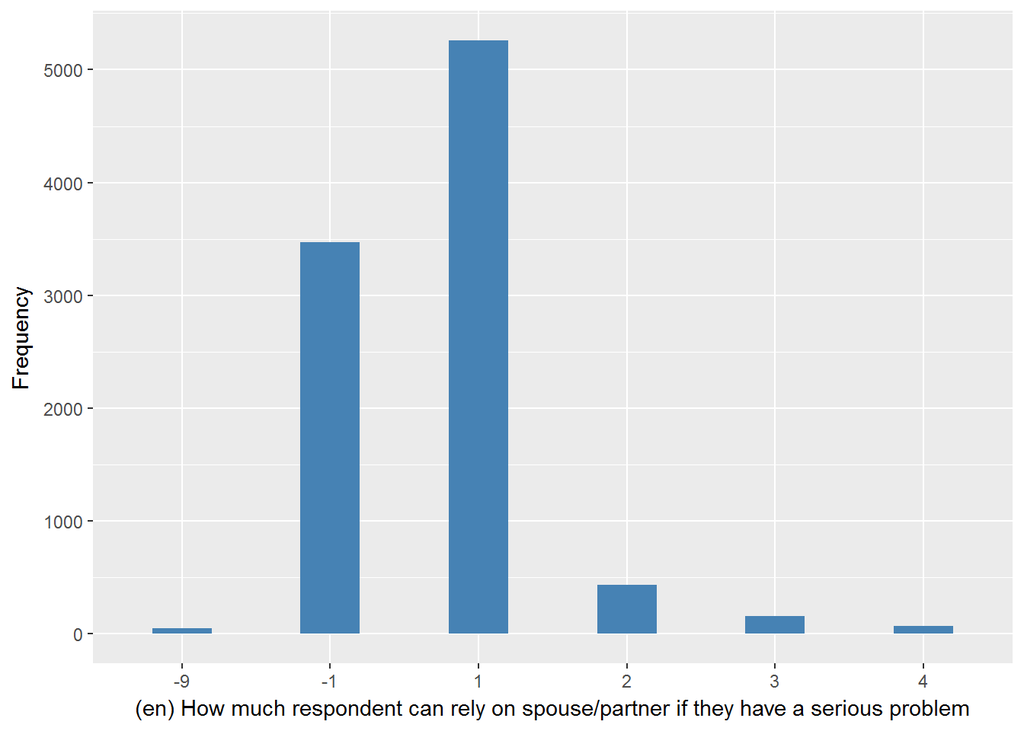

scptrc

| Sample size | Missing values |
| --- | --- |
| 9432 | 3523 |

Category

|  | 1 | 2 | 3 | 4 |
| --- | --- | --- | --- | --- |
| Frequency | 4078.00 | 1305.00 | 381.00 | 145.00 |
| Percentage | 43.24 | 13.84 | 4.04 | 1.54 |

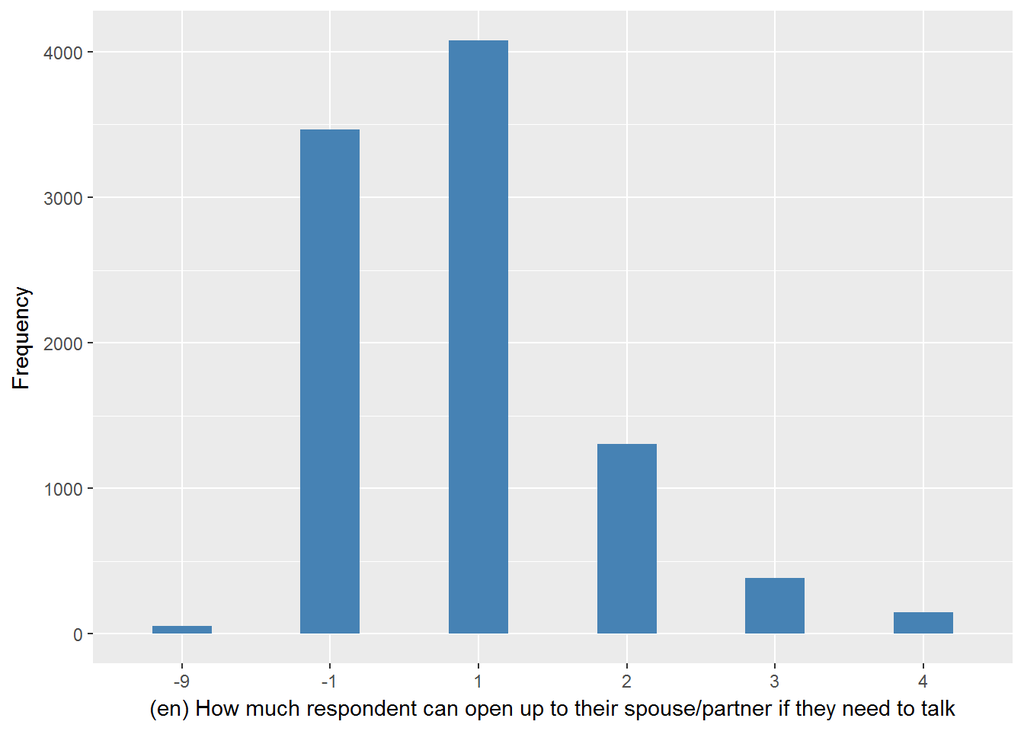

scchda

| Sample size | Missing values |
| --- | --- |
| 9432 | 2392 |

Category

|  | 1 | 2 | 3 | 4 |
| --- | --- | --- | --- | --- |
| Frequency | 2882.00 | 3040.00 | 911.00 | 207.00 |
| Percentage | 30.56 | 32.23 | 9.66 | 2.19 |

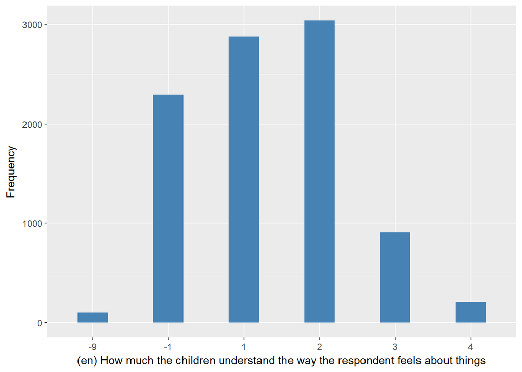

scchdb

| Sample size | Missing values |
| --- | --- |
| 9432 | 2357 |

Category

|  | 1 | 2 | 3 | 4 |
| --- | --- | --- | --- | --- |
| Frequency | 5433.0 | 1044.00 | 421.00 | 177.00 |
| Percentage | 57.6 | 11.07 | 4.46 | 1.88 |

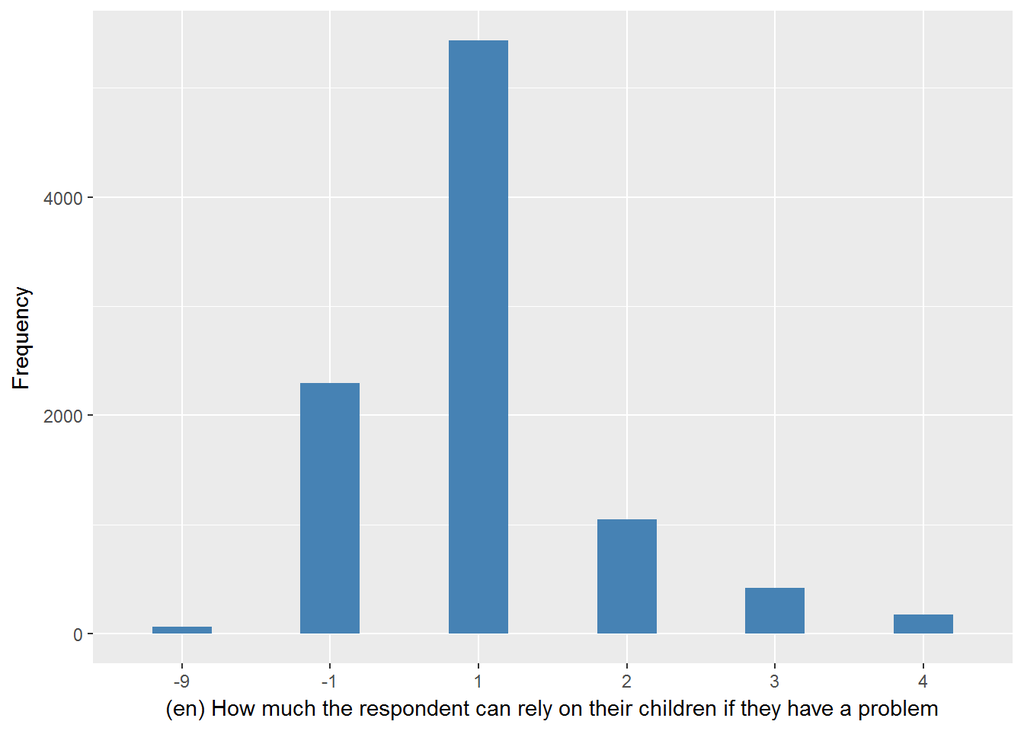

scchdc

| Sample size | Missing values |
| --- | --- |
| 9432 | 2378 |

Category

|  | 1 | 2 | 3 | 4 |
| --- | --- | --- | --- | --- |
| Frequency | 3521.00 | 2272.00 | 931.00 | 330.0 |
| Percentage | 37.33 | 24.09 | 9.87 | 3.5 |

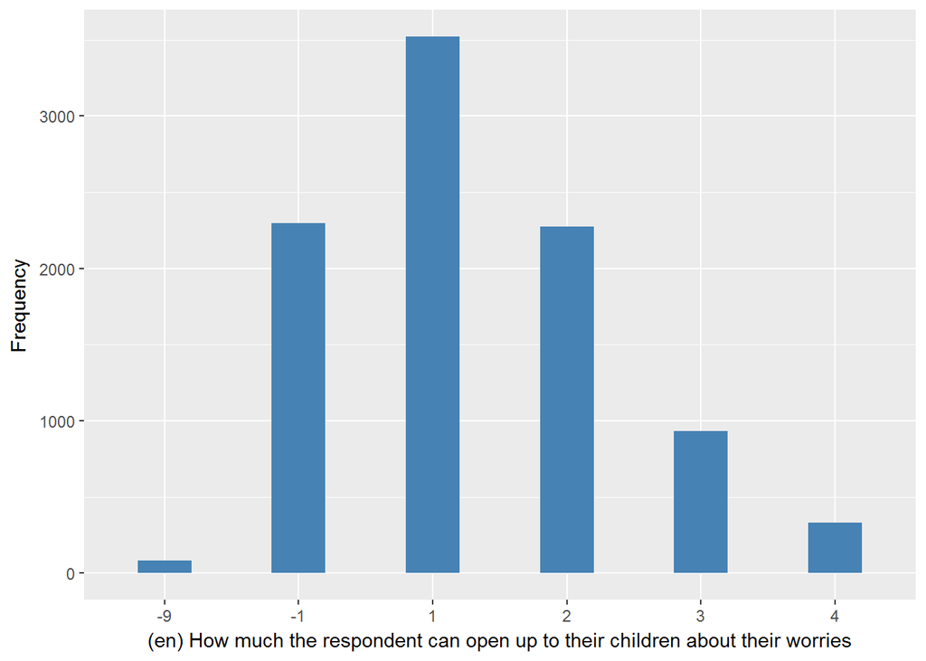

scfama

| Sample size | Missing values |
| --- | --- |
| 9432 | 1971 |

Category

|  | 1 | 2 | 3 | 4 |
| --- | --- | --- | --- | --- |
| Frequency | 1691.00 | 2913.00 | 2000.0 | 857.00 |
| Percentage | 17.93 | 30.88 | 21.2 | 9.09 |

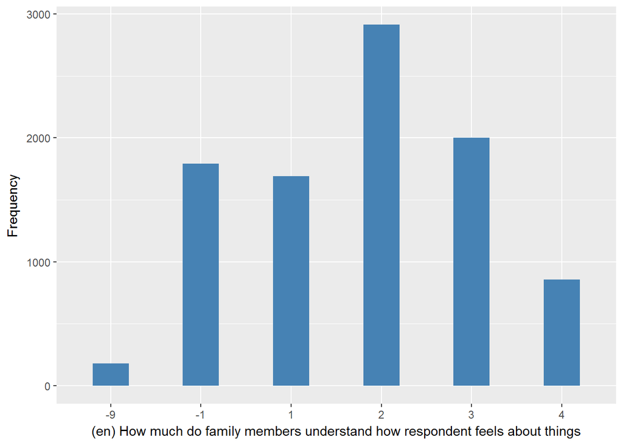

scfamb

| Sample size | Missing values |
| --- | --- |
| 9432 | 1943 |

Category

|  | 1 | 2 | 3 | 4 |
| --- | --- | --- | --- | --- |
| Frequency | 3541.00 | 1784.00 | 1249.00 | 915.0 |
| Percentage | 37.54 | 18.91 | 13.24 | 9.7 |

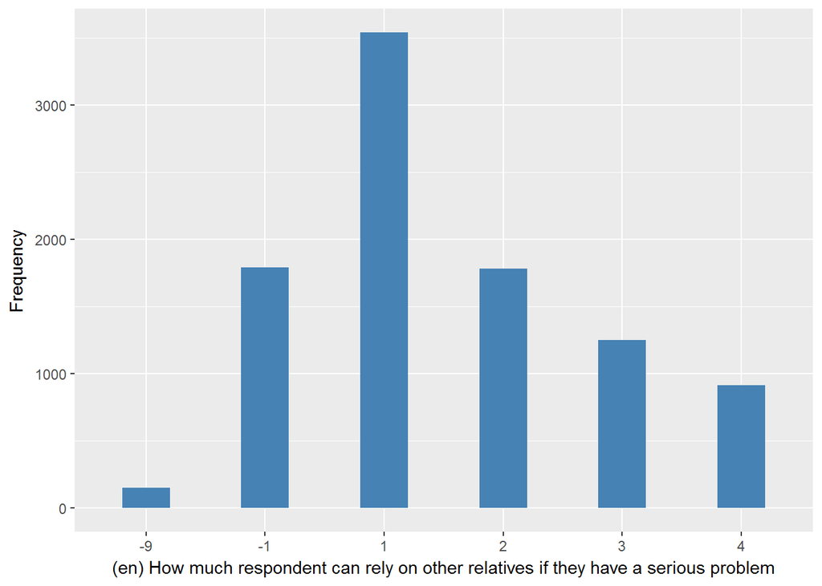

scfamc

| Sample size | Missing values |
| --- | --- |
| 9432 | 1957 |

Category

|  | 1 | 2 | 3 | 4 |
| --- | --- | --- | --- | --- |
| Frequency | 2268.00 | 2241.00 | 1757.00 | 1209.00 |
| Percentage | 24.05 | 23.76 | 18.63 | 12.82 |

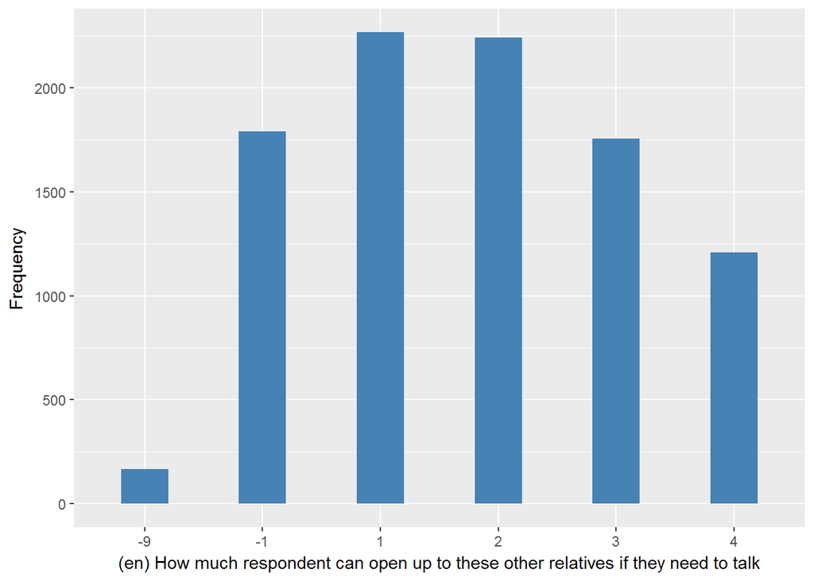

scfrda

| Sample size | Missing values |
| --- | --- |
| 9432 | 1665 |

Category

|  | 1 | 2 | 3 | 4 |
| --- | --- | --- | --- | --- |
| Frequency | 2720.00 | 3473.00 | 1420.00 | 154.00 |
| Percentage | 28.84 | 36.82 | 15.06 | 1.63 |

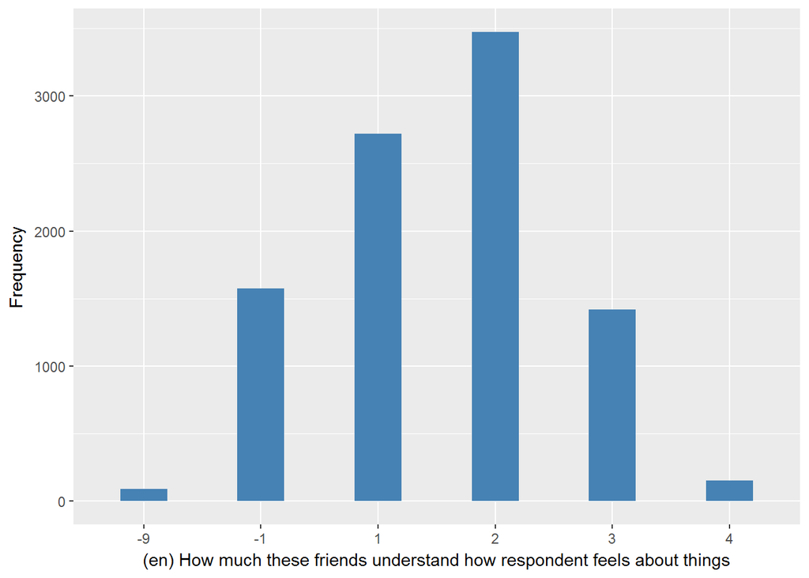

scfrdb

| Sample size | Missing values |
| --- | --- |
| 9432 | 1652 |

Category

|  | 1 | 2 | 3 | 4 |
| --- | --- | --- | --- | --- |
| Frequency | 3893.00 | 2427.00 | 1198.0 | 262.00 |
| Percentage | 41.27 | 25.73 | 12.7 | 2.78 |

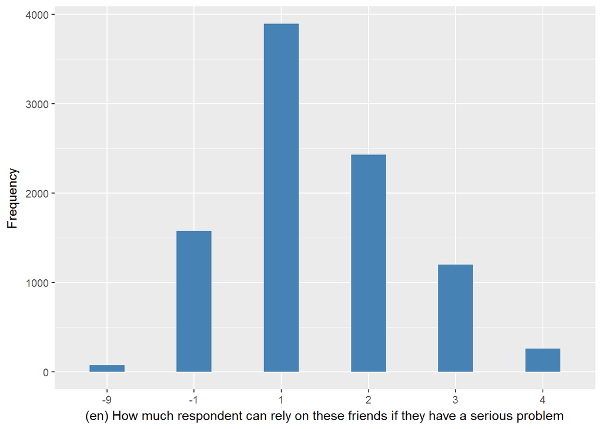

scfrdc

| Sample size | Missing values |
| --- | --- |
| 9432 | 1663 |

Category

|  | 1 | 2 | 3 | 4 |
| --- | --- | --- | --- | --- |
| Frequency | 3006.00 | 2721.00 | 1599.00 | 443.0 |
| Percentage | 31.87 | 28.85 | 16.95 | 4.7 |

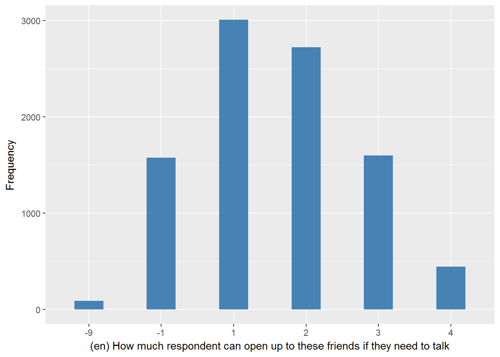

#### 2.1.2.2 Harmonisation algorithm

To compute the harmonize variable from the study-specific variable it has to be recoded as follows:

- `if any variable equals 1 or 2 then 1`
- `if all are equal 3 or 4 then 0`
- `-1 into 996`
- `-9 into 995`
- `NA into 999`

**R script:**

```r
ELSA_ds_w2 <- tibble(id = ELSA_w2_emot_sup$id)

ELSA_w2_emot_sup$scptra <- car::recode(as.vector(ELSA_w2_emot_sup$scptra), "NA='-999'")
ELSA_w2_emot_sup$scptrb <- car::recode(as.vector(ELSA_w2_emot_sup$scptrb), "NA='-999'")
ELSA_w2_emot_sup$scptrc <- car::recode(as.vector(ELSA_w2_emot_sup$scptrc), "NA='-999'")
ELSA_w2_emot_sup$scchda <- car::recode(as.vector(ELSA_w2_emot_sup$scchda), "NA='-999'")
ELSA_w2_emot_sup$scchdb <- car::recode(as.vector(ELSA_w2_emot_sup$scchdb), "NA='-999'")
ELSA_w2_emot_sup$scchdc <- car::recode(as.vector(ELSA_w2_emot_sup$scchdc), "NA='-999'")
ELSA_w2_emot_sup$scfama <- car::recode(as.vector(ELSA_w2_emot_sup$scfama), "NA='-999'")
ELSA_w2_emot_sup$scfamb <- car::recode(as.vector(ELSA_w2_emot_sup$scfamb), "NA='-999'")
ELSA_w2_emot_sup$scfamc <- car::recode(as.vector(ELSA_w2_emot_sup$scfamc), "NA='-999'")
ELSA_w2_emot_sup$scfrda <- car::recode(as.vector(ELSA_w2_emot_sup$scfrda), "NA='-999'")
ELSA_w2_emot_sup$scfrdb <- car::recode(as.vector(ELSA_w2_emot_sup$scfrdb), "NA='-999'")
ELSA_w2_emot_sup$scfrdc <- car::recode(as.vector(ELSA_w2_emot_sup$scfrdc), "NA='-999'")


ELSA_ds_w2$emot_sup <- c(NA)
for (i in 1:dim(ELSA_w2_emot_sup)[1]) {
    if (ELSA_w2_emot_sup$scptra[i] %in% c(1, 2) | ELSA_w2_emot_sup$scptrb[i] %in%
        c(1, 2) | ELSA_w2_emot_sup$scptrc[i] %in% c(1, 2) | ELSA_w2_emot_sup$scchda[i] %in%
        c(1, 2) | ELSA_w2_emot_sup$scchdb[i] %in% c(1, 2) | ELSA_w2_emot_sup$scchdc[i] %in%
        c(1, 2) | ELSA_w2_emot_sup$scfama[i] %in% c(1, 2) | ELSA_w2_emot_sup$scfamb[i] %in%
        c(1, 2) | ELSA_w2_emot_sup$scfamc[i] %in% c(1, 2) | ELSA_w2_emot_sup$scfrda[i] %in%
        c(1, 2) | ELSA_w2_emot_sup$scfrdb[i] %in% c(1, 2) | ELSA_w2_emot_sup$scfrdc[i] %in%
        c(1, 2)) {
        ELSA_ds_w2$emot_sup[i] = 1
    } else if (ELSA_w2_emot_sup$scptra[i] == -1 & ELSA_w2_emot_sup$scptrb[i] ==
        -1 & ELSA_w2_emot_sup$scptrc[i] == -1 & ELSA_w2_emot_sup$scchda[i] ==
        -1 & ELSA_w2_emot_sup$scchdb[i] == -1 & ELSA_w2_emot_sup$scchdc[i] ==
        -1 & ELSA_w2_emot_sup$scfama[i] == -1 & ELSA_w2_emot_sup$scfamb[i] ==
        -1 & ELSA_w2_emot_sup$scfamc[i] == -1 & ELSA_w2_emot_sup$scfrda[i] ==
        -1 & ELSA_w2_emot_sup$scfrdb[i] == -1 & ELSA_w2_emot_sup$scfrdc[i] ==
        -1) {
        ELSA_ds_w2$emot_sup[i] = 996
    } else if (ELSA_w2_emot_sup$scptra[i] %in% c(3, 4, -1) & ELSA_w2_emot_sup$scptrb[i] %in%
        c(3, 4, -1) & ELSA_w2_emot_sup$scptrc[i] %in% c(3, 4, -1) & ELSA_w2_emot_sup$scchda[i] %in%
        c(3, 4, -1) & ELSA_w2_emot_sup$scchdb[i] %in% c(3, 4, -1) & ELSA_w2_emot_sup$scchdc[i] %in%
        c(3, 4, -1) & ELSA_w2_emot_sup$scfama[i] %in% c(3, 4, -1) & ELSA_w2_emot_sup$scfamb[i] %in%
        c(3, 4, -1) & ELSA_w2_emot_sup$scfamc[i] %in% c(3, 4, -1) & ELSA_w2_emot_sup$scfrda[i] %in%
        c(3, 4, -1) & ELSA_w2_emot_sup$scfrdb[i] %in% c(3, 4, -1) & ELSA_w2_emot_sup$scfrdc[i] %in%
        c(3, 4, -1)) {
        ELSA_ds_w2$emot_sup[i] = 0
    } else if (ELSA_w2_emot_sup$scptra[i] == -9 | ELSA_w2_emot_sup$scptrb[i] ==
        -9 | ELSA_w2_emot_sup$scptrc[i] == -9 | ELSA_w2_emot_sup$scchda[i] ==
        -9 | ELSA_w2_emot_sup$scchdb[i] == -9 | ELSA_w2_emot_sup$scchdc[i] ==
        -9 | ELSA_w2_emot_sup$scfama[i] == -9 | ELSA_w2_emot_sup$scfamb[i] ==
        -9 | ELSA_w2_emot_sup$scfamc[i] == -9 | ELSA_w2_emot_sup$scfrda[i] ==
        -9 | ELSA_w2_emot_sup$scfrdb[i] == -9 | ELSA_w2_emot_sup$scfrdc[i] ==
        -9) {
        ELSA_ds_w2$emot_sup[i] = 995
    }
}

ELSA_ds_w2$emot_sup <- car::recode(as.vector(ELSA_ds_w2$emot_sup), "NA='999'")
ELSA_ds_w2$emot_sup <- labelled(ELSA_ds_w2$emot_sup, labels = c(No = 0, Yes = 1,
    Missing = 999, `Do not know` = 998, Refuse = 997, `Not applicable` = 996,
    `Don't answer` = 995, `Not attempt/not done/not yet recorded` = 994, `Disable to measure` = 993,
    Impute = 992, `CAPI/interviewer error` = 991))
```

#### 2.1.2.3 Statistics of the new harmonised variable

Receives emotional support from someone

| Sample size | Missing values |
| --- | --- |
| 9432 | 1120 |

Category

|  | 0 | 1 |
| --- | --- | --- |
| Frequency | 47.0 | 8265.00 |
| Percentage | 0.5 | 87.63 |

Type of missing

|  | 991 | 992 | 993 | 994 | 995 | 996 | 997 | 998 | 999 | NA |
| --- | --- | --- | --- | --- | --- | --- | --- | --- | --- | --- |
| Frequency | 0 | 0 | 0 | 0 | 20.00 | 1100.00 | 0 | 0 | 0 | 0 |
| Percentage | 0 | 0 | 0 | 0 | 0.21 | 11.66 | 0 | 0 | 0 | 0 |

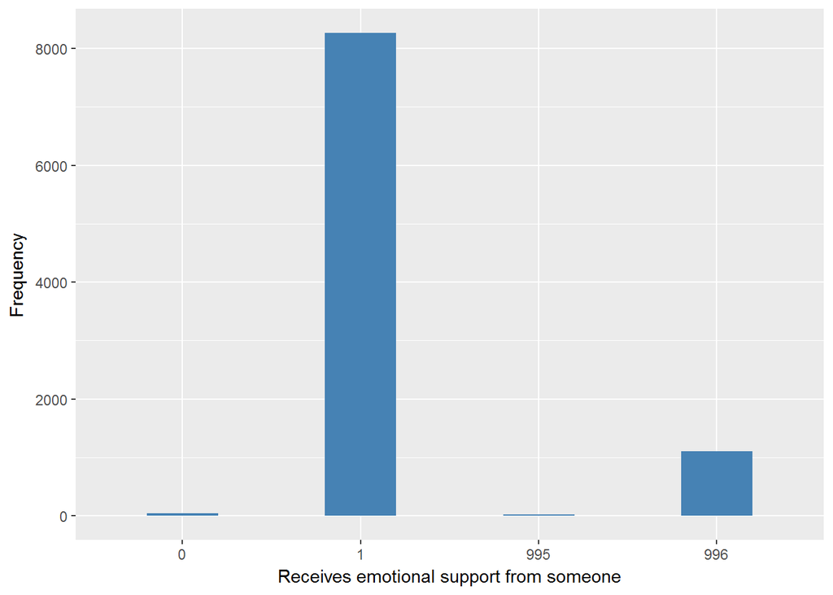

#### 2.1.2.4 Validation

### 2.1.3 Wave 3

#### 2.1.3.1 Study-specific variable description

| **Name** | `scptra` | `scptrb` | `scptrc` | `scchda` | `scchdb` | `scchdc` | `scfama` | `scfamb` | `scfamc` | `scfrda` | `scfrdb` | `scfrdc` |
| --- | --- | --- | --- | --- | --- | --- | --- | --- | --- | --- | --- | --- |
| **Label** | `how much does your spouse/partner really understand the way you feel?` | `how much can you rely on your spouse/partner if you have a serious problem?` | `how much can you open up to your spouse/partner if you need to talk about your worries?` | `how much do your children really understand the way you feel about things?` | `how much can you rely on your children if you have a serious problem?` | `how much can you open up to your children if you need to talk about your worries?` | `how much do these family members really understand the way you feel?` | `how much can you rely on these family members if you have a serious problem?` | `how much can you open up to these family members if you need to talk about your worries?` | `how much do your friends really understand the way you feel about things?` | `how much can you rely on these friends if you have a serious problem?` | `how much can you open up to these friends if you need to talk about your worries?` |
| **Table name** | `wave_3_elsa_data_v4` | `wave_3_elsa_data_v4` | `wave_3_elsa_data_v4` | `wave_3_elsa_data_v4` | `wave_3_elsa_data_v4` | `wave_3_elsa_data_v4` | `wave_3_elsa_data_v4` | `wave_3_elsa_data_v4` | `wave_3_elsa_data_v4` | `wave_3_elsa_data_v4` | `wave_3_elsa_data_v4` | `wave_3_elsa_data_v4` |
| **Categories** | `1 = A lot` `2 = Some` `3 = A little` `4 = Not at all` | `1 = A lot` `2 = Some` `3 = A little` `4 = Not at all` | `1 = A lot` `2 = Some` `3 = A little` `4 = Not at all` | `1 = A lot` `2 = Some` `3 = A little` `4 = Not at all` | `1 = A lot` `2 = Some` `3 = A little` `4 = Not at all` | `1 = A lot` `2 = Some` `3 = A little` `4 = Not at all` | `1 = A lot` `2 = Some` `3 = A little` `4 = Not at all` | `1 = A lot` `2 = Some` `3 = A little` `4 = Not at all` | `1 = A lot` `2 = Some` `3 = A little` `4 = Not at all` | `1 = A lot` `2 = Some` `3 = A little` `4 = Not at all` | `1 = A lot` `2 = Some` `3 = A little` `4 = Not at all` | `1 = A lot` `2 = Some` `3 = A little` `4 = Not at all` |
| **Missings** | `-9 = Not answered` `-1 = Item not applicable` `-8 = Don't know` | `-9 = Not answered` `-8 = Don't know` `-1 = Item not applicable` | `-9 = Not answered` `-8 = Don't know` `-1 = Item not applicable` | `-9 = Not answered` `-8 = Don't know` `-1 = Item not applicable` | `-9 = Not answered` `-8 = Don't know` `-1 = Item not applicable` | `-9 = Not answered` `-8 = Don't know` `-1 = Item not applicable` | `-9 = Not answered` `-8 = Don't know` `-1 = Item not applicable` | `-9 = Not answered` `-8 = Don't know` `-1 = Item not applicable` | `-9 = Not answered` `-8 = Don't know` `-1 = Item not applicable` | `-9 = Not answered` `-8 = Don't know` `-1 = Item not applicable` | `-9 = Not answered` `-8 = Don't know` `-1 = Item not applicable` | `-9 = Not answered` `-8 = Don't know` `-1 = Item not applicable` |
| **Description** |  |  |  |  |  |  |  |  |  |  |  |  |

scptra

| Sample size | Missing values |
| --- | --- |
| 9771 | 3856 |

Category

|  | 1 | 2 | 3 | 4 |
| --- | --- | --- | --- | --- |
| Frequency | 3584.00 | 1865.00 | 386.00 | 80.00 |
| Percentage | 36.68 | 19.09 | 3.95 | 0.82 |

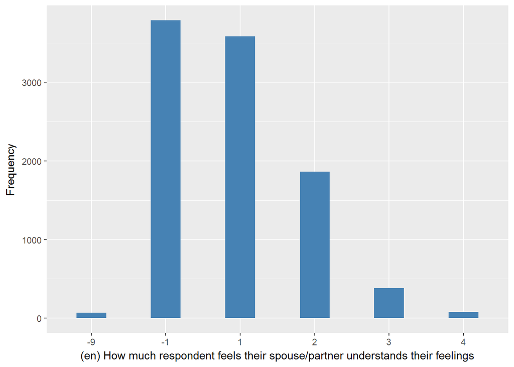

scptrb

| Sample size | Missing values |
| --- | --- |
| 9771 | 3844 |

Category

|  | 1 | 2 | 3 | 4 |
| --- | --- | --- | --- | --- |
| Frequency | 5359.00 | 385.00 | 135.00 | 48.00 |
| Percentage | 54.85 | 3.94 | 1.38 | 0.49 |

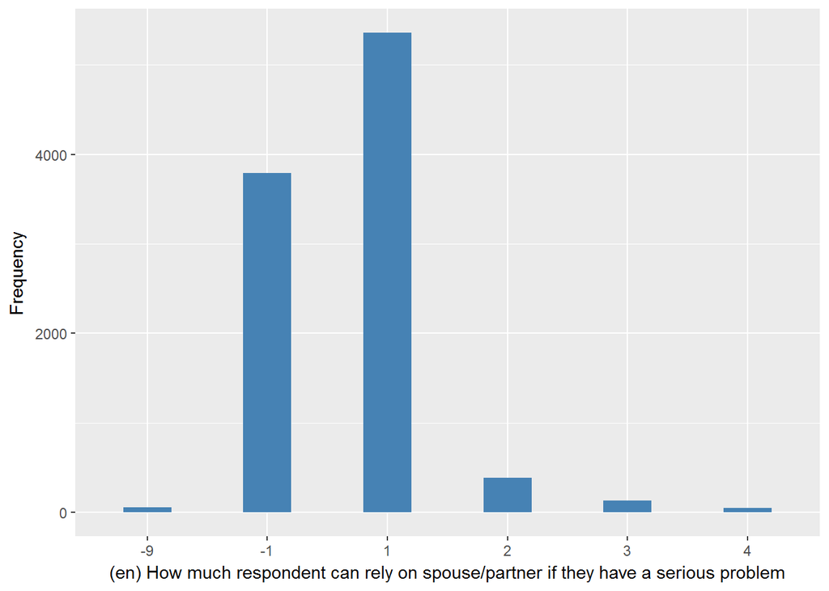

scptrc

| Sample size | Missing values |
| --- | --- |
| 9771 | 3849 |

Category

|  | 1 | 2 | 3 | 4 |
| --- | --- | --- | --- | --- |
| Frequency | 4096.00 | 1365.00 | 351.00 | 110.00 |
| Percentage | 41.92 | 13.97 | 3.59 | 1.13 |

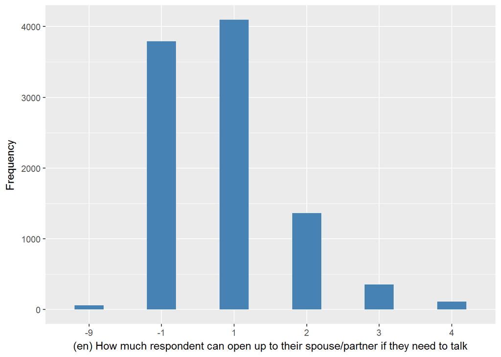

scchda

| Sample size | Missing values |
| --- | --- |
| 9771 | 2790 |

Category

|  | 1 | 2 | 3 | 4 |
| --- | --- | --- | --- | --- |
| Frequency | 2991.00 | 2978.00 | 817.00 | 195 |
| Percentage | 30.61 | 30.48 | 8.36 | 2 |